# OHI+ China 2015 Assessment Report

## Introduction

The Ocean Health Index (OHI) framework assesses how healthy oceans are by using available information to score a suite of benefits called goals. Independent assessments using the OHI framework are called ‘OHI+’ assessments, and scores are calculated using the best available local information, incorporated as inputs and target reference points to calculate goal models. The purpose of OHI+ assessments is to customize the OHI framework methodology to best represent the local context being assessed, encompassing the local vision of what a healthy ocean is and what it should provide.

Note that OHI goals have a two-letter code (example: FP = Food Provision) and any sub-goals have a three-letter code (example: MAR = Mariculture).

## Summary: OHI+ China 2015

### Assessment information

**The OHI+ China assessment scored 10 goals in 11 regions.** The overall OHI+ Index score for China was 58. This is the area-weighted average of scores calculated for each goal in every region.

The OHI+ China assessment was able to use local information for many of the inputs, including goal models, pressures and resilience. The following compares local information to information used from the 2014 global assessment:

- **overall, OHI+ China used 71.43% local information**
- goal models used 100% local information
- pressures components used 80% local information
- resilience components used 36.36% local information

### Major modifications

- LSP’s reference point is changed to 5% protection, which is a management goal set by Chinese marine resource management and protection agencies to achieve by 2020.
- For MAR, we used coastal area permitted for mariculture as the area data, which produces a more realistic representation of mariculture status than using the entire coastal area for calculation.
- CS model included a new variable, relative carbon sequestration rate of each habitat. Together with habitat extent, these two variables provide a more complete picture of how habitats contribute to CS than extent alone could do.
- TR incorporated both international and local tourists data.

### Suggestions for improvement

Mostly the assessment would benefit from higher quality, time-series data.

- Habitat data are scarce for some regions. Habitat trend was calculated based on available data. When there was only one year of data, the trend was assumed to be -0.1.
- Species area data was missing. SPP model wasn’t able to incorporate area data at all, reslting in an incomplete picture of the status of SPP and BD.
- AO model needs to be revisited. (Need to edit: Current model is not good)
- FIS catch data collection needs to be standardized and at finer scale. See the Goal Model Comparison table below for more detail.

### OHI+ China scores table

Explore scores for the OHI+ China assessment. There are scores for the 11 regions as well as an overall China score.

| goal | region_name | score |
| --- | --- | --- |
| AO | China | 53.5 |
| BD | China | 54.5 |
| CP | China | 37.2 |
| CS | China | 39.6 |
| CW | China | 73.1 |
| ECO | China | 54 |
| FIS | China | 13.8 |
| FP | China | 38 |
| HAB | China | 53.8 |
| ICO | China | 58.9 |

[output cut: 218 more lines]

### OHI+ China figures

#### Flower plot: China

Flower plots represent Index scores (inside circle) and individual goal scores (coloured petals). The outer ring is the maximum possible score for each goal, and a goal’s score is represented by the petal’s length from the center circle (0) to the outer ring (100, a perfect score in relation to the goal’s reference point). The weight (relative contribution) of each goal is represented by the petal’s width. Grey indicates that a goal is not relevant to that reporting region.

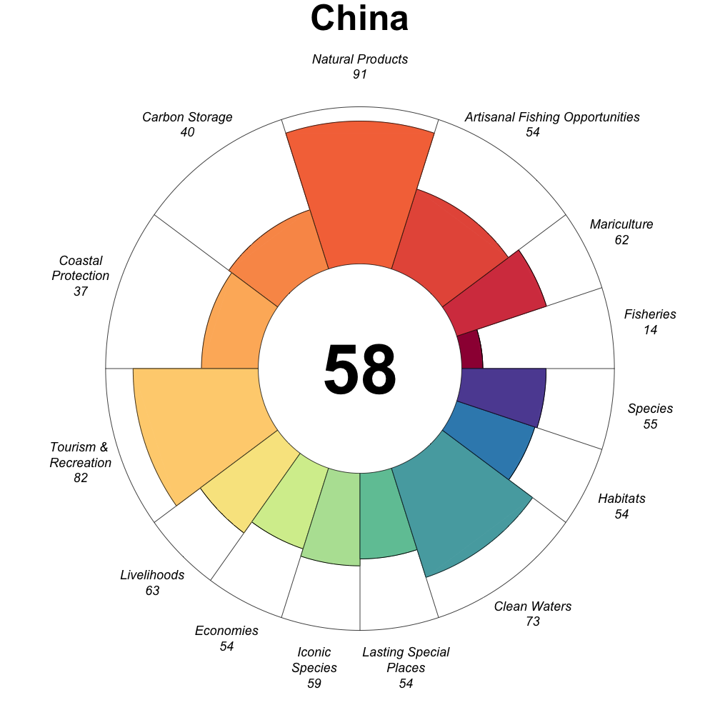

## Comparison: OHI+ China vs. OHI global assessments

### How scores can be compared across assessments

The purpose of any OHI+ assessment is to customize the OHI framework methodology to best represent the local context being assessed, which can mean different visions of what a healthy ocean is and what it should provide. This makes OHI+ scores not directly comparable to scores calculated in any other assessment, including global assessments that are based on coarser-scale information, models, and reference points.

However, while direct, quantitative comparison of scores from China with scores from other assessments is limited, qualitative comparisons can be made because assessments use a consistent framework. It can be valuable to make such comparisons to see which locations are closer to achieving their stated management targets and learn about how goals were modeled and targets were set.

### Methods comparison table

This table compares models and reference points from the OHI 2014 global assessment with the OHI+ 2015 China assessment. Note that some methods have improved since the original Halpern *et al*. 2012 global assessment and were published in Halpern *et al*. 2015. These improvements are also indicated in the table below.

[output not shown]

### Scores comparison table

**The OHI+ China assessment scored (58), is lower than that of the 2014 global study (62).

[Click here](http://htmlpreview.github.io/?https://github.com/OHI-Science/chn/blob/draft/province2015/reports/compare_scores_global_china.html) to view a full comparison table of 2014 global OHI scores for China, China OHI+ scores, and the differences between them. The table colors differences from blue to red, with blue indicating the largest positive difference and red indicating the largest negative difference.

### Narrative regarding differences

Regional assessment scores of CW, LSP, NP, and TR are higher than the global assessments. Reasons vary. CW and TR models are modified and different variables are incorporated. LSP and NP reference points are changed, which are easier to achieve than those in the global study.

Most goal scores are lower than their counterparts in the global study. AO has the most drastic reduction in score.

## To update this report

This report was written with [Rmarkdown](http://rmarkdown.rstudio.com/) and can be updated as scores change. You can edit `chn/province2015/reports/report_china2015.rmd` locally in RStudio and push to GitHub.